# Gating cells in cytoverse - Part 2

# Background

In this section we describe the methods available to access and extract the gated data within a `GatingSet`. It is important to note here that the **gates** essentially act as filter for the data and may be utilize to subset the original data.

```r
library(flowWorkspace)
library(flowCore)
```

## Gating paths: get and set

Let’s first look at the gates that are attached to the `GatingSet`. For this example, we will make use of a `GatingSet` that we have previously prepared (The script used to prepare this `GatingSet` is available [here](https://github.com/Sanduni-P/flow-cytometry-workshop/blob/main/vignettes/make_transformed_gs_func.R).

```r
gs <- load_gs(path = "data/gating-set/")
gs
```

```
A GatingSet with 4 samples
```

We have previously used `plot(gs)` to visualize the gating hierarchy as a tree as shown below:

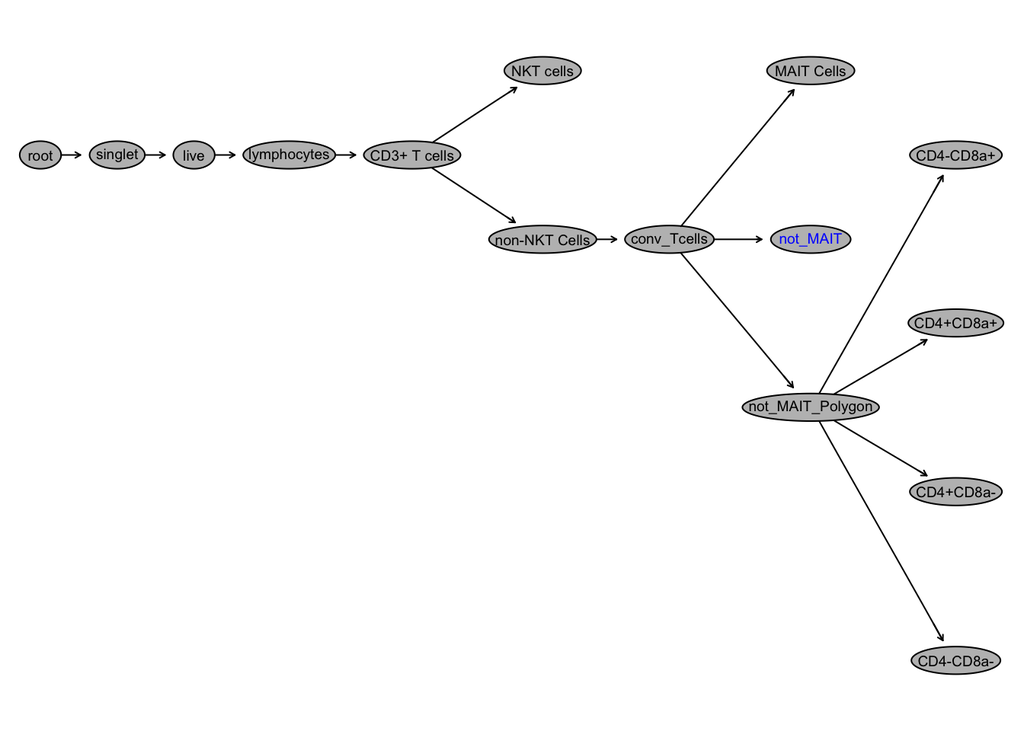

To extract the full gating path we can use `gs_get_pop_paths` method.

```r
# get all paths
gs_get_pop_paths(gs)
```

```
 [1] "root"
 [2] "/singlet"
 [3] "/singlet/live"
 [4] "/singlet/live/lymphocytes"
 [5] "/singlet/live/lymphocytes/CD3+ T cells"
 [6] "/singlet/live/lymphocytes/CD3+ T cells/NKT cells"
 [7] "/singlet/live/lymphocytes/CD3+ T cells/non-NKT Cells"
 [8] "/singlet/live/lymphocytes/CD3+ T cells/non-NKT Cells/conv_Tcells"
 [9] "/singlet/live/lymphocytes/CD3+ T cells/non-NKT Cells/conv_Tcells/MAIT Cells"
[10] "/singlet/live/lymphocytes/CD3+ T cells/non-NKT Cells/conv_Tcells/not_MAIT"
[11] "/singlet/live/lymphocytes/CD3+ T cells/non-NKT Cells/conv_Tcells/not_MAIT_Polygon"
[12] "/singlet/live/lymphocytes/CD3+ T cells/non-NKT Cells/conv_Tcells/not_MAIT_Polygon/CD4-CD8a+"
[13] "/singlet/live/lymphocytes/CD3+ T cells/non-NKT Cells/conv_Tcells/not_MAIT_Polygon/CD4+CD8a+"
[14] "/singlet/live/lymphocytes/CD3+ T cells/non-NKT Cells/conv_Tcells/not_MAIT_Polygon/CD4+CD8a-"
[15] "/singlet/live/lymphocytes/CD3+ T cells/non-NKT Cells/conv_Tcells/not_MAIT_Polygon/CD4-CD8a-"
```

When there are a lot of gates, this list can become very long as each node is shown as a distinct path. Suppose you would like to only view the leaf nodes. For this, we use `gs_get_leaf_nodes`.

```r
# get leaf nodes
gs_get_leaf_nodes(
  gs,
  ancestor = "root") # can select leafs of a specific node
```

```
[1] "/singlet/live/lymphocytes/CD3+ T cells/NKT cells"
[2] "/singlet/live/lymphocytes/CD3+ T cells/non-NKT Cells/conv_Tcells/MAIT Cells"
[3] "/singlet/live/lymphocytes/CD3+ T cells/non-NKT Cells/conv_Tcells/not_MAIT"
[4] "/singlet/live/lymphocytes/CD3+ T cells/non-NKT Cells/conv_Tcells/not_MAIT_Polygon/CD4-CD8a+"
[5] "/singlet/live/lymphocytes/CD3+ T cells/non-NKT Cells/conv_Tcells/not_MAIT_Polygon/CD4+CD8a+"
[6] "/singlet/live/lymphocytes/CD3+ T cells/non-NKT Cells/conv_Tcells/not_MAIT_Polygon/CD4+CD8a-"
[7] "/singlet/live/lymphocytes/CD3+ T cells/non-NKT Cells/conv_Tcells/not_MAIT_Polygon/CD4-CD8a-"
```

To change the name of a node, for instance, **CD4-CD8a-** above is not super clear and we want to update this to **Double Negative CD3+ T cells** for readability, we can use `gs_pop_set_name` method.

```r
# rename node
gs_pop_set_name(
  gs,
  "CD4-CD8a-",
  "Double Negative CD3+ T cells")
```

```
$`4000_TNK-CR1`
NULL

$`4001_TNK-CR1`
NULL

$`4002_TNK-CR1`
NULL

$`4003_TNK-CR1`
NULL
```

```r
# check
gs_get_leaf_nodes(gs)
```

```
[1] "/singlet/live/lymphocytes/CD3+ T cells/NKT cells"
[2] "/singlet/live/lymphocytes/CD3+ T cells/non-NKT Cells/conv_Tcells/MAIT Cells"
[3] "/singlet/live/lymphocytes/CD3+ T cells/non-NKT Cells/conv_Tcells/not_MAIT"
[4] "/singlet/live/lymphocytes/CD3+ T cells/non-NKT Cells/conv_Tcells/not_MAIT_Polygon/CD4-CD8a+"
[5] "/singlet/live/lymphocytes/CD3+ T cells/non-NKT Cells/conv_Tcells/not_MAIT_Polygon/CD4+CD8a+"
[6] "/singlet/live/lymphocytes/CD3+ T cells/non-NKT Cells/conv_Tcells/not_MAIT_Polygon/CD4+CD8a-"
[7] "/singlet/live/lymphocytes/CD3+ T cells/non-NKT Cells/conv_Tcells/not_MAIT_Polygon/Double Negative CD3+ T cells"
```

### Exercise

1. Run `gs_get_pop_paths(gs)` by include a `path = 1` argument. How is the output different compared to not providing `path`? What happens when you change this to `path = 2`?
2. Suppose you do not know what is the parent population for `Double Negative CD3+ T cells`, what is an easy approach to get this information? *Hint*: Try `help(gs_pop_get_paths)` to check other available methods.

## Extracting filtered data

Often, users may also want to extract the embedded expression data for a specified gated population for some downstream application. The `cytoverse` makes it super easy to extract this data. Moreover, the extracted data is preserved as a `cytoframe` or a `cytoset` for ease of use.

The 2 main methods are: 1. `gs_pop_get_data` 2. `gh_pop_get_data`

```r
# extract data
extracted <- gs_pop_get_data(gs,
                y = "live",
                inverse.transform = FALSE)
extracted
```

```
A cytoset with 4 samples.

  column names:
    FSC-A, FSC-H, SSC-A, B515-A, B610-A, B660-A, B710-A, B780-A, G575-A, G610-A, G660-A, G710-A, G780-A, R670-A, R730-A, R780-A, U390-A, U450-A, U500-A, U570-A, U660-A, U740-A, U785-A, V450-A, V510-A, V570-A, V605-A, V655-A, V710-A, V750-A, V785-A, remove_from_FS_FM, Time

cytoset has been subsetted and can be realized through 'realize_view()'.
```

### Exercise

1. Try running the above code as `gh_pop_get_data`. How are the results different?
2. Extract the data from the gate `Double Negative CD3+ T cells` for the 1st sample and store it as `sample_1`. Transform the expression value for `FSC-A`. What happens to the data in `gs`?*Hint*

```
# plot
ggcyto(gs,
       subset = "Double Negative CD3+ T cells",
       aes(x = "FSC-A", y = "SSC-A"))+
  geom_hex(bins = 256)
```

Notice that altering the extracted data leads to altered data within the `GatingSet`. This is because we did not create a new copy of the data using `realize_view` method. Importantly, this further highlights that the `cytoframe`, `cytoset`, and the `GatingSet` are all pointing to the same data!

3. what does `inverse.transform` argument do?
4. Run the following code:

This is only for example.

```r
another_CD3_gate <- matrix(c(-Inf,Inf), nrow = 2, ncol=1)
colnames(another_CD3_gate) <- "FSC-A"
another_CD3_gate <- rectangleGate(.gate = another_CD3_gate, filterId = "CD3+ T cells")
gs_pop_add(gs, parent = "non-NKT Cells", gate = another_CD3_gate)
recompute(gs)
plot(gs)
```

Now try to extract the `CD3+ T cells` population using either `gs_` or `gh_` methods as above.

## Saving extracted data

Depending on the method called, the extracted data is either preserved as a `cytoframe` or a `cytoset`. As you experienced in the exercise, manipulating the extracted without performing a deep copy using `realize_view` leads to alteration of the data within the `GatingSet` object. As such, if extracting for further downstream application, it maybe worthwhile to save the data. For this, please refer to the Importing and Basics of working with FCS files for more details.

# Conclusion

In this brief section we demonstrated how users/analysts could extract the embedded data from a `GatingSet`. Feel free to explore the `flowWorkspace` vignette for additional available methods. In the next section, Reporting, we will go over how to extract various statistics regarding the gated populations.